# Introduction to R

Etka Yapar

10/27/2020

# Working in the Console

Console of the RStudio is the primary interface we will be interacting with the R session running in the background.

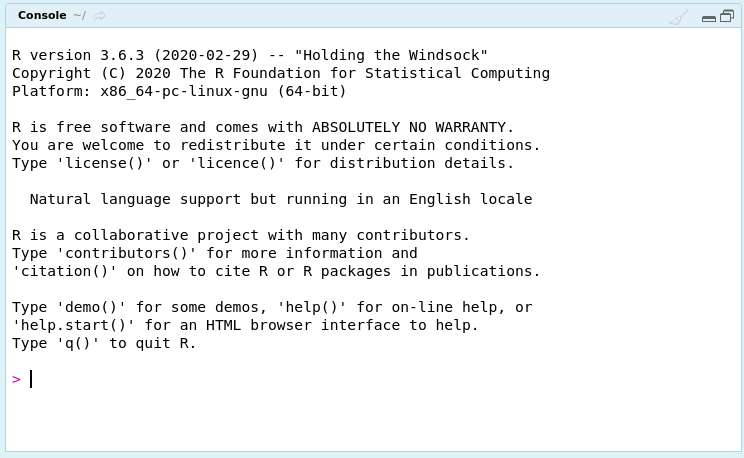

## Simple math operations

We can use R as a pocket calculator by using simple mathematical operations that are available. Below, you can find some of them that are accessible through usage of *operators* which are usually single character symbols that tells R to do a specific tasks. In this case you are seeing some *arithmetic operators* in the below table.

| Operation | Operator |
| --- | --- |
| Addition | + |
| Subtraction | - |
| Division | / |
| Multiplication | * |
| Exponentiation | ^ |
| Modulo | %% |

Let’s try some sample math operations

```r
5 + 8
```

```
## [1] 13
```

```r
23 / 8
```

```
## [1] 2.875
```

```r
2^(14 * 3) * 0.5
```

```
## [1] 2.199023e+12
```

Noticed that weird notation for the output of the last example command? You may be familiar with it if you use spreadsheet programs like MS Excel, its a way to show numbers in the scientific notation. So it just means $2.199023 \times 10^{12}$

## Creating variables

Being able to use R for typing out mathematical expressions and getting the results back is nice, but what if you are to find the result out of a long and complicated operation or you are doing a set of operations that each depend on each others result? It would be convenient if we could save the result of some operations. This is what *variables* are for. Creating a variable is just like putting a name tag on a value, it can be a standalone value or result of some operation. We can create variables using the `=` operator.

```r
x = 5
y = 8
long_math = 3 * (8^3) / 0.5 * 10^8
```

We can use the created variables in an expression:

```r
x * y / 12
```

```
## [1] 3.333333
```

Or just type their name into the console and retrieve the contained value:

```r
long_math
```

```
## [1] 3.072e+11
```

To see the created variables we can look into the environment pane of RStudio

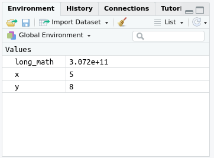

or use the `ls()` function

```r
ls()
```

```
## [1] "long_math" "x"         "y"
```

## Different classes of variables

There are different classes of variables that will hold different classes of data. For now we will focus on two of them `numeric` and `character`. At this point we already created three different numeric variables actually, we can check the class of a variable using the `class()` function.

```r
class(long_math)
```

```
## [1] "numeric"
```

```r
class(x)
```

```
## [1] "numeric"
```

```r
class(y)
```

```
## [1] "numeric"
```

as you can see they are all of class `numeric`, and if we check the values stored inside them:

```r
long_math
```

```
## [1] 3.072e+11
```

```r
x
```

```
## [1] 5
```

```r
y
```

```
## [1] 8
```

we can see that even though the first is actually a floating point number and the remaining two are just integers, r refers to them as simply `numeric`.

Now, let’s look into some examples of `character` values / variables.

```r
"If you surround something with double or single quotes"
```

```
## [1] "If you surround something with double or single quotes"
```

```r
"You just created a character value"
```

```
## [1] "You just created a character value"
```

```r
char_var = "You can create variables with them too"
my_name = "etka"
```

```r
char_var
```

```
## [1] "You can create variables with them too"
```

```r
my_name
```

```
## [1] "etka"
```

There is a third class that is actually really useful named `factor` and in summary, it is the way `R` stores and represents categorical information but we will see them in detail once we start to deal with datasets.

# Using the RScript

While the console is nice, it is hard to keep track of our code when we use the console alone. For this reason we will `RScript`s to store and edit our data. You can create a new `RScript` by Clicking on following menu items: `File-> New File -> R Script` and you should see a new pane appearing on the top left side of your `RStudio` window like this:

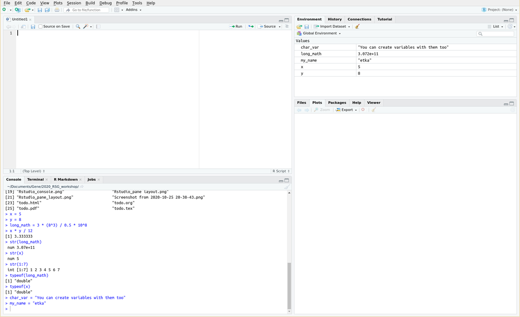

When you type a valid R code to your script window and hit enter nothing happens this is because that window normally works like a simple text editor (e.g. NotePad) when you type inside. To send a line of code to the console for evaluation, you can hit `ctrl+enter` while your cursor is on anywhere that line or, if you want to evaluate several lines of code, you can select (highlight) those lines with your mouse and then hit `ctrl+enter`. macOS users can do the same by using the `command+enter` key combination.

# More Operators

## Comparison operators

These are group of operators that you can use to compare different values against each other. You can a table of comparison operators below

| Operator | Symbol |
| --- | --- |
| Less than | < |
| Greater than | > |
| Is equal to | == |
| Less than or eq.to | <= |
| Greater than or eq.to | >= |
| Is not equal to | != |

Let’s try to do some comparisons using them and our previously created numeric variables `x` and `y`

```r
x
```

```
## [1] 5
```

```r
y
```

```
## [1] 8
```

```r
x < y
```

```
## [1] TRUE
```

```r
x == y
```

```
## [1] FALSE
```

```r
x > y
```

```
## [1] FALSE
```

```r
y > 3.56
```

```
## [1] TRUE
```

```r
12 > x
```

```
## [1] TRUE
```

Suprisingly they can also be used to compare to `character` values:

```r
my_name
```

```
## [1] "etka"
```

```r
my_surname = "yapar"
```

```r
my_name == "etka"
```

```
## [1] TRUE
```

```r
my_name < my_surname
```

```
## [1] TRUE
```

```r
"b" < "a"
```

```
## [1] FALSE
```

```r
"alpha" < "beta"
```

```
## [1] TRUE
```

As you can see `>` and `<` operators work by comparing `characters` according to alphabetical order.

Note that the result values we see as `TRUE` and `FALSE` are of different class called `logical`, and can be written in their shorter forms, `T` and `F`, respectively.

```r
class(TRUE)
```

```
## [1] "logical"
```

```r
T == TRUE
```

```
## [1] TRUE
```

```r
F == FALSE
```

```
## [1] TRUE
```

## Logical operators

Logical operators perform operations like `AND` and `OR` that we know from logic / math classes of the past. Let’s remember how these two operators work briefly:

| Operator | Operand 1 | Operand 2 | Outcome |
| --- | --- | --- | --- |
|  | T | T | T |
| **AND** | T | F | F |
|  | F | F | F |
|  | T | T | T |
| **OR** | T | F | T |
|  | F | F | F |

AND and OR operations can be accessed via their operators in R, `&` and `|`, respectively.

Let’s do some examples using them:

```r
T & F
```

```
## [1] FALSE
```

```r
my_name == "etka" | my_surname == "sabanci"
```

```
## [1] TRUE
```

Ever wondered why you see `[1]` in the beginning of every console output when you run something? It is a topic related to a data structure called `vector` in R. Let’s find out!

# Vectors

Vectors are used to store multiple values in one single variable. We can create vectors using the `c()` function and type in values (or variable names) separated by `,` :

```r
my_vec = c(2, 8, x, 48, y)
my_vec
```

```
## [1]  2  8  5 48  8
```

Now, I would like to show you two built-in vectors ,`letters` and `LETTERS`, to demonstrate the meaning of `[1]` in the console output. Those vectors store lowercase and uppercase letters of the english alphabet

```r
letters
```

```
##  [1] "a" "b" "c" "d" "e" "f" "g" "h" "i" "j" "k" "l" "m" "n" "o" "p" "q" "r" "s"
## [20] "t" "u" "v" "w" "x" "y" "z"
```

```r
LETTERS
```

```
##  [1] "A" "B" "C" "D" "E" "F" "G" "H" "I" "J" "K" "L" "M" "N" "O" "P" "Q" "R" "S"
## [20] "T" "U" "V" "W" "X" "Y" "Z"
```

```r
c(letters,LETTERS)
```

```
##  [1] "a" "b" "c" "d" "e" "f" "g" "h" "i" "j" "k" "l" "m" "n" "o" "p" "q" "r" "s"
## [20] "t" "u" "v" "w" "x" "y" "z" "A" "B" "C" "D" "E" "F" "G" "H" "I" "J" "K" "L"
## [39] "M" "N" "O" "P" "Q" "R" "S" "T" "U" "V" "W" "X" "Y" "Z"
```

Now, you can see that, `[1]` and other ones that appeared in the second and the third lines are just telling us the order of the first element (in the original vector) that appear on beginning of each line of console output. For instance, element `"t"` is the 20th and element `"M"` is the 39th element in the vector `c(letters, LETTERS)`.

> But then, you might ask *“So why do we see `[1]` even if we type the name of variables like `x` or `my_name`, they are not vectors they are values by themselves!”* The answer to this mystery is actually quite simple: there are no scalars in `R`, meaning there is no data structure to contain a singular value. All those past variables we created were actually represented as vectors with length 1 in R!

Okay, now that numbers-in-brackets thing is covered, let’s try something interesting

```r
char_vec = c("collection", "of", "words")
numr_vec = c(3, 4, 95, 1, 63)

mosaic_vec = c("Some", "words", "and", 4, 6, 10)
```

```r
char_vec
```

```
## [1] "collection" "of"         "words"
```

```r
class(char_vec)
```

```
## [1] "character"
```

```r
numr_vec
```

```
## [1]  3  4 95  1 63
```

```r
class(numr_vec)
```

```
## [1] "numeric"
```

```r
mosaic_vec
```

```
## [1] "Some"  "words" "and"   "4"     "6"     "10"
```

```r
class(mosaic_vec)
```

```
## [1] "character"
```

we didn’t get any warning or errors when we created `mosaic_vec` but when we view its contents (and also check its class directly) we can see that all the -originally numeric- values are converted to characters. This is because vectors can only store elements of same class, and since numbers have their conterparts as characters too, converting everything to character makes sense if the end goal is losing less data as possible.

## Arithmetic operations on vectors

Now that we have learned about R not having scalars, let us see some examples on arithmetic operations on vectors with more than one element.

```r
numbers  = 1:6 ## N:J notation to create the sequence {N, N+1, N+2, ..., J}
numbers2 = 6:1 ## It works in reverse too !

numbers ; numbers2 ## We can combine two lines of code into one apparent line by using semicolon
```

```
## [1] 1 2 3 4 5 6
```

```
## [1] 6 5 4 3 2 1
```

```r
numbers * 2
```

```
## [1]  2  4  6  8 10 12
```

```r
numbers + numbers2
```

```
## [1] 7 7 7 7 7 7
```

As you can see from last two code chunks, if two vectors have the same length, corresponding elements are used for selected operation, in this case addition. If one is shorter than the other, shorter vector will be re-cycyled (repeated) until it has the same length as the longer vector.

So,

```r
c(1,2,3) + 1
```

actually operates like:

```r
c(1,2,3) + c(1,1,1)
```

and

```r
c(1,2,3,4,5,6) + c(1,2)
```

actually operates like:

```r
c(1,2,3,4,5,6) + c(1,2,1,2,1,2)
```

we get a warning only if the longer vector’s length is indivisible by that of the shorter one (e.g. 7 vs 3):

```r
c(1,2,3,4,5,6,7) + c(1,2,3)
```

```
## Warning in c(1, 2, 3, 4, 5, 6, 7) + c(1, 2, 3): longer object length is not a
## multiple of shorter object length
```

```
## [1] 2 4 6 5 7 9 8
```

and it operates like:

```r
c(1,2,3,4,5,6,7) + c(1,2,3,1,2,3,1)
```

```
## [1] 2 4 6 5 7 9 8
```

There are some useful functions we can use that do arithmetic operations or provide descriptive statistics like `log()`, `sum()`, `mean()`, `median()`, `sd()`, `var()`, etc.

for details you can type `?functionName` for any function to see built-in help pages available. For now we will see `sum()` and `mean()`

```r
to_sum = c(30, 50, 80)
sum(to_sum)
```

```
## [1] 160
```

```r
mean(to_sum)
```

```
## [1] 53.33333
```

```r
mean(to_sum) == sum(to_sum) / 3
```

```
## [1] TRUE
```

## Some attributes of vectors

### length

We already talked about vectors with different lengths, but not how to retrieve the length of a vector. `length()` function exactly does that:

```r
numbers ; length(numbers)
```

```
## [1] 1 2 3 4 5 6
```

```
## [1] 6
```

### names

It is possible to assign names to a vector such that each element would get its own name. When you create vector with the `c()` function in the way we saw until now there are no names. We can use the `names()` function to retrieve or set the names attribute for a vector:

```r
my_grades = c(80, 45, 100, 19, 60)
my_grades
```

```
## [1]  80  45 100  19  60
```

```r
names(my_grades)
```

[output not shown]

since we didn’t define any names when creating the `my_grades` vector, when we try to retrieve the names with `names()` we get back `NULL`, which is R’s way of telling that this attribute is not defined. Now, let’s try to set the names for the `my_grades` vector.

```r
names(my_grades) = c("mt1", "quiz1", "quiz2",
                     "mt2", "final")
my_grades
```

```
##   mt1 quiz1 quiz2   mt2 final
##    80    45   100    19    60
```

```r
names(my_grades)
```

```
## [1] "mt1"   "quiz1" "quiz2" "mt2"   "final"
```

Since names attribute is set such that each element gets its own name, it is important to provide a character vector with the same length as the original vector when we are using `names()` to set the names attribute of a vector.

## Comparison along a vector

Remember the comparison operators we have learned before,now let’s see what happens if we use these operators on vectors:

```r
my_grades
```

```
##   mt1 quiz1 quiz2   mt2 final
##    80    45   100    19    60
```

```r
passing = my_grades >= 60
outside_curve = my_grades == 100

passing
```

```
##   mt1 quiz1 quiz2   mt2 final
##  TRUE FALSE  TRUE FALSE  TRUE
```

```r
outside_curve
```

```
##   mt1 quiz1 quiz2   mt2 final
## FALSE FALSE  TRUE FALSE FALSE
```

```r
passing & outside_curve
```

```
##   mt1 quiz1 quiz2   mt2 final
## FALSE FALSE  TRUE FALSE FALSE
```

# Lists

Lists, like vectors, can store multiple elements but have a more flexible nature in that they can hold elements that have different classes. Like we have the `c()` function for creating vectors, we have the `list()` function for creating lists.

```r
mosaic_list = list("Some", "words", "and", 4, 6, 10, T, F)
mosaic_list
```

```
## [[1]]
## [1] "Some"
##
## [[2]]
## [1] "words"
##
## [[3]]
## [1] "and"
##
## [[4]]
## [1] 4
##
## [[5]]
## [1] 6
##
## [[6]]
## [1] 10
##
## [[7]]
## [1] TRUE
##
## [[8]]
## [1] FALSE
```

Different from vectors we should use `[[]]` instead of `[]`.

```r
mosaic_list[[1]]
```

```
## [1] "Some"
```

```r
mosaic_list[[7]]
```

```
## [1] TRUE
```

```r
class(mosaic_list[[1]]) ; class(mosaic_list[[7]])
```

```
## [1] "character"
```

```
## [1] "logical"
```

Let’s see what happens if we `[]` use instead:

```r
mosaic_list[1]
```

```
## [[1]]
## [1] "Some"
```

```r
mosaic_list[7]
```

```
## [[1]]
## [1] TRUE
```

```r
class(mosaic_list[1]) ; class(mosaic_list[7])
```

```
## [1] "list"
```

```
## [1] "list"
```

as you can see, when we use `[]` for subsetting lists, we get back lists instead of the vectors stored inside respective elements.

List elements can also have names, just like vector names:

```r
shopping_list = list(etka = c("detergent", "cigarettes"),
                     ulas = c("coffee", "sugar", "banana"),
                     melike = c("tea", "cream", "bread",
                                "milk"))
```

```r
shopping_list
```

```
## $etka
## [1] "detergent"  "cigarettes"
##
## $ulas
## [1] "coffee" "sugar"  "banana"
##
## $melike
## [1] "tea"   "cream" "bread" "milk"
```

In addition to use the name inside square brackets for subsetting, for lists, we can use the dollar sign (`$`) for accessing individual list elements by their names:

```r
shopping_list[["etka"]]
```

```
## [1] "detergent"  "cigarettes"
```

```r
shopping_list$etka
```

```
## [1] "detergent"  "cigarettes"
```